# K-Nearest Neighbors Classification with Recursive Feature Elimination and Genetic Algorithm for Detecting Adulteration in Ground Coffee: Spectral Preprocessing by Multiplicative Scatter Correction, Sa

## Train Models

### K-Nearest Neighbors

- We will train a k-Nearest Neighbors (kNN) model using sparse variables selected by the RFE and GA algorithms, further reduced through Principal Component Analysis (PCA).

```r
# Set random seed for reproducibility
set.seed (123)

# Set up the training control(10 folds 10 times cross_validation)
control <- trainControl(method = "repeatedcv", number = 10, repeats = 10,
                        classProbs = TRUE, savePredictions = "final",
                        summaryFunction = multiClassSummary,
                        selectionFunction = 'oneSE', allowParallel = TRUE)

# OneSE rule will be used to select simplest yet optimal model within the 'best model'
```

```r
#Set the metric as accuracy
metric<-"Accuracy"
```

```r
# Set up the grid for tuning to find the optimal value of k. Ensure the value is odd
grid <- expand.grid(.k = seq(3, 30, by = 2))
```

```r
#Register cluster for caret to train the models in parallel
cl<-makeCluster(6,type = "SOCK")
suppressWarnings(suppressMessages(
  registerDoSNOW(cl)))

# Start_time
start_time<-Sys.time()

#Train the model using cross-validation (10 folds, 10 times)
fit_knn_msc_sg_2d<-train(y = train_mergedPreprocessed[,1],
                         x = train_mergedPreprocessed[,-1],
                         method = 'knn', tuneGrid =  grid,
                         trControl = control,
                         metric = 'Accuracy') #unmodified data
#End_time
end_time<-Sys.time()

model_training_time<-end_time-start_time

stopCluster(cl) # Stop the parallel run cluster

print(model_training_time)
```

```
Time difference of 17.20498 secs
```

```r
#Register cluster for caret to train the models in parallel
cl<-makeCluster(6,type = "SOCK")
suppressWarnings(suppressMessages(
  registerDoSNOW(cl)))

# Start_time
start_time<-Sys.time()
fit_knn_snv_smote_msc_sg_2d <- train(y = train_merged_smote_Preprocessed[,1],
                         x = train_merged_smote_Preprocessed[,-1],
                         method = 'knn', tuneGrid =  grid,
                         trControl = control,
                         metric = 'Accuracy') # SMOTE data

#End_time
end_time<-Sys.time()

model_training_time<-end_time-start_time

stopCluster(cl) # Stop the parallel run cluster

print(model_training_time)
```

```
Time difference of 27.33187 secs
```

```r
# Display model results for imbalanced data
print(fit_knn_msc_sg_2d)
```

```
k-Nearest Neighbors

1055 samples
   7 predictor
   2 classes: 'adulterated', 'pure_arabica'

No pre-processing
Resampling: Cross-Validated (10 fold, repeated 10 times)
Summary of sample sizes: 949, 949, 949, 950, 949, 950, ...
Resampling results across tuning parameters:

  k   logLoss      AUC        prAUC       Accuracy   Kappa      F1
   3  0.003878459  0.9999703  0.02275873  0.9977278  0.9751167  0.9988044
   5  0.005132086  0.9999207  0.03404958  0.9968751  0.9661981  0.9983561
   7  0.007359696  0.9998612  0.03553811  0.9959272  0.9549215  0.9978590
   9  0.008433688  0.9998166  0.03620776  0.9943208  0.9384681  0.9970118
  11  0.009402440  0.9997944  0.04859647  0.9924241  0.9187227  0.9960127
  13  0.010413383  0.9996976  0.06115676  0.9912884  0.9086104  0.9954092
  15  0.011206648  0.9996877  0.07465602  0.9906253  0.9017750  0.9950600
  17  0.012211437  0.9996778  0.09526849  0.9905310  0.9008166  0.9950102
  19  0.012956081  0.9996777  0.14233070  0.9905310  0.9008166  0.9950102
  21  0.013861031  0.9996579  0.23107724  0.9905310  0.9008166  0.9950102
  23  0.015144236  0.9996381  0.31831496  0.9905310  0.9008166  0.9950102
  25  0.016759240  0.9995488  0.35512458  0.9906253  0.9017750  0.9950600
  27  0.018147242  0.9994097  0.36164617  0.9908149  0.9035201  0.9951605
  29  0.019500274  0.9992954  0.36776086  0.9914780  0.9094756  0.9955127
  Sensitivity  Specificity  Pos_Pred_Value  Neg_Pred_Value  Precision
  0.9985089    0.9805       0.9991176       0.9776786       0.9991176
  0.9974178    0.9850       0.9993128       0.9567619       0.9993128
  0.9974168    0.9640       0.9983265       0.9581190       0.9983265
  0.9960307    0.9580       0.9980285       0.9359643       0.9980285
  0.9940446    0.9580       0.9980265       0.9012738       0.9980265
  0.9928545    0.9580       0.9980265       0.8860476       0.9980265
  0.9921594    0.9580       0.9980236       0.8728810       0.9980236
  0.9920604    0.9580       0.9980236       0.8712143       0.9980236
  0.9920604    0.9580       0.9980236       0.8712143       0.9980236
  0.9920604    0.9580       0.9980236       0.8712143       0.9980236
  0.9920604    0.9580       0.9980236       0.8712143       0.9980236
  0.9921594    0.9580       0.9980236       0.8728810       0.9980236
  0.9923584    0.9580       0.9980246       0.8760714       0.9980246
  0.9930535    0.9580       0.9980246       0.8852024       0.9980246
  Recall     Detection_Rate  Balanced_Accuracy
  0.9985089  0.9530948       0.9895045
  0.9974178  0.9520526       0.9912089
  0.9974168  0.9520526       0.9807084
  0.9960307  0.9507300       0.9770153
  0.9940446  0.9488334       0.9760223
  0.9928545  0.9476977       0.9754272
  0.9921594  0.9470346       0.9750797
  0.9920604  0.9469403       0.9750302
  0.9920604  0.9469403       0.9750302
  0.9920604  0.9469403       0.9750302
  0.9920604  0.9469403       0.9750302
  0.9921594  0.9470346       0.9750797
  0.9923584  0.9472242       0.9751792
  0.9930535  0.9478873       0.9755267

Accuracy was used to select the optimal model using  the one SE rule.
The final value used for the model was k = 3.
```

```r
# Display results for data balanced by SMOTE
print(fit_knn_snv_smote_msc_sg_2d)
```

```
k-Nearest Neighbors

1872 samples
   6 predictor
   2 classes: 'adulterated', 'pure_arabica'

No pre-processing
Resampling: Cross-Validated (10 fold, repeated 10 times)
Summary of sample sizes: 1685, 1684, 1685, 1685, 1685, 1685, ...
Resampling results across tuning parameters:

  k   logLoss       AUC  prAUC        Accuracy   Kappa      F1
   3  9.992007e-16  1    0.000000000  1.0000000  1.0000000  1.0000000
   5  4.211358e-04  1    0.001590420  1.0000000  1.0000000  1.0000000
   7  1.667966e-03  1    0.003892140  0.9998396  0.9996786  0.9998324
   9  3.008135e-03  1    0.005977066  0.9984506  0.9968975  0.9983922
  11  4.523285e-03  1    0.008224439  0.9962610  0.9925138  0.9961300
  13  5.721141e-03  1    0.008224439  0.9962075  0.9924067  0.9960741
  15  6.808010e-03  1    0.008224439  0.9954065  0.9908022  0.9952374
  17  7.802725e-03  1    0.008770903  0.9941768  0.9883392  0.9939543
  19  8.738924e-03  1    0.009371715  0.9932689  0.9865203  0.9930040
  21  9.563574e-03  1    0.009645843  0.9919869  0.9839534  0.9916755
  23  1.034783e-02  1    0.010467630  0.9919869  0.9839534  0.9916755
  25  1.111027e-02  1    0.011068442  0.9919869  0.9839534  0.9916755
  27  1.189503e-02  1    0.013090908  0.9919869  0.9839534  0.9916755
  29  1.260666e-02  1    0.014968073  0.9919869  0.9839534  0.9916755
  Sensitivity  Specificity  Pos_Pred_Value  Neg_Pred_Value  Precision
  1.0000000    1            1               1.0000000       1
  1.0000000    1            1               1.0000000       1
  0.9996703    1            1               0.9996970       1
  0.9968192    1            1               0.9970397       1
  0.9923256    1            1               0.9928232       1
  0.9922157    1            1               0.9927222       1
  0.9905721    1            1               0.9912114       1
  0.9880459    1            1               0.9888838       1
  0.9861825    1            1               0.9871770       1
  0.9835511    1            1               0.9847216       1
  0.9835511    1            1               0.9847216       1
  0.9835511    1            1               0.9847216       1
  0.9835511    1            1               0.9847216       1
  0.9835511    1            1               0.9847216       1
  Recall     Detection_Rate  Balanced_Accuracy
  1.0000000  0.4871772       1.0000000
  1.0000000  0.4871772       1.0000000
  0.9996703  0.4870167       0.9998352
  0.9968192  0.4856278       0.9984096
  0.9923256  0.4834381       0.9961628
  0.9922157  0.4833846       0.9961079
  0.9905721  0.4825836       0.9952861
  0.9880459  0.4813540       0.9940229
  0.9861825  0.4804460       0.9930913
  0.9835511  0.4791640       0.9917756
  0.9835511  0.4791640       0.9917756
  0.9835511  0.4791640       0.9917756
  0.9835511  0.4791640       0.9917756
  0.9835511  0.4791640       0.9917756

Accuracy was used to select the optimal model using  the one SE rule.
The final value used for the model was k = 5.
```

## **Save the models for future use**

```r
saveRDS(fit_knn_msc_sg_2d, "fit_knn_msc_sg_2d.rds")
saveRDS(fit_knn_snv_smote_msc_sg_2d, "fit_knn_smote_msc_sg_2d.rds")
```

## Plot the cross-validation results —–> Model Selection for optimal k

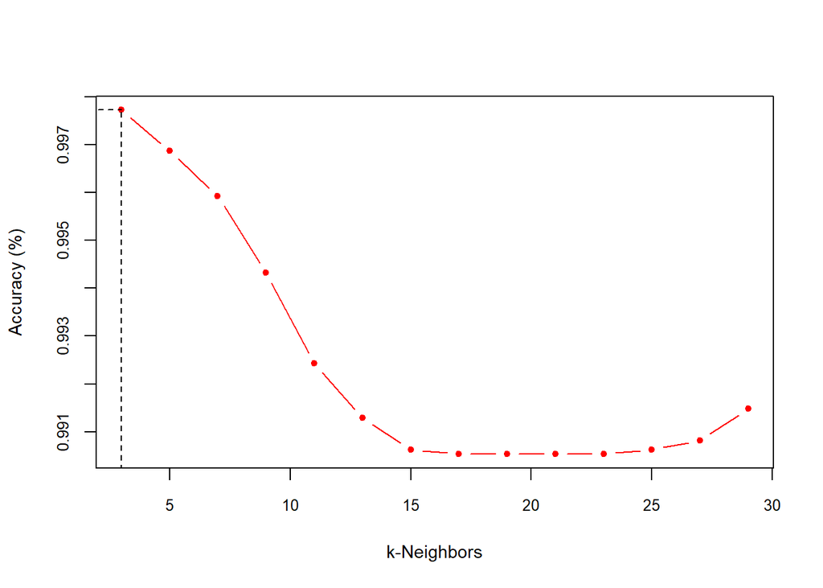

```r
# Imbalanced Data
k_data<-fit_knn_msc_sg_2d$results
best_k = fit_knn_msc_sg_2d$bestTune$k
y_Acc = k_data$Accuracy[k_data$k == best_k]
plot(k_data$k,k_data$Accuracy, type = "b",col = "red",pch = 20,cex.axis = 0.8,
     xlab = "k-Neighbors", ylab = "Accuracy (%)",cex.lab = 0.9)
# Add line from x-axis to the specific point
segments(x0 = best_k, y0 = 0, x1 = best_k, y1 = y_Acc, col = "black", lty = 2)

# Add line from y-axis to the specific point
segments(x0 = 0, y0 = y_Acc, x1 = best_k, y1 = y_Acc, col = "black", lty = 2)
```

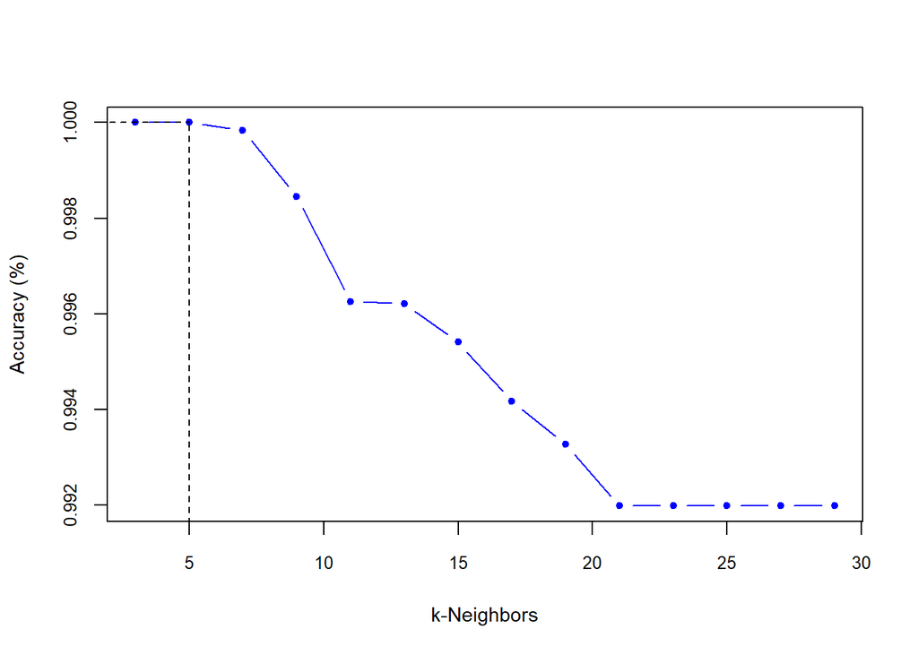

```r
# SMOTE Data
k_data<-fit_knn_snv_smote_msc_sg_2d$results
best_k = fit_knn_snv_smote_msc_sg_2d$bestTune$k
y_Acc = k_data$Accuracy[k_data$k == best_k]
plot(k_data$k,k_data$Accuracy, type = "b",col = "blue",pch = 20,cex.axis = 0.8,
     xlab = "k-Neighbors", ylab = "Accuracy (%)",cex.lab = 0.9)
# Add line from x-axis to the specific point
segments(x0 = best_k, y0 = 0, x1 = best_k, y1 = y_Acc, col = "black", lty = 2)

# Add line from y-axis to the specific point
segments(x0 = 0, y0 = y_Acc, x1 = best_k, y1 = y_Acc, col = "black", lty = 2)
```

## Display the cross-validation results

```r
print(paste('The optimal value of k for the models is', fit_knn_msc_sg_2d$bestTune)) #unmodified data
```

```
[1] "The optimal value of k for the models is 3"
```

```r
print(paste('The optimal value of k for the models is', fit_knn_snv_smote_msc_sg_2d$bestTune)) #SMOTE data
```

```
[1] "The optimal value of k for the models is 5"
```

## Display CV Results in Tables

```r
kable(fit_knn_msc_sg_2d$results)
```

| k | logLoss | AUC | prAUC | Accuracy | Kappa | F1 | Sensitivity | Specificity | Pos_Pred_Value | Neg_Pred_Value | Precision | Recall | Detection_Rate | Balanced_Accuracy | logLossSD | AUCSD | prAUCSD | AccuracySD | KappaSD | F1SD | SensitivitySD | SpecificitySD | Pos_Pred_ValueSD | Neg_Pred_ValueSD | PrecisionSD | RecallSD | Detection_RateSD | Balanced_AccuracySD |
| --- | --- | --- | --- | --- | --- | --- | --- | --- | --- | --- | --- | --- | --- | --- | --- | --- | --- | --- | --- | --- | --- | --- | --- | --- | --- | --- | --- | --- |
| 3 | 0.0038785 | 0.9999703 | 0.0227587 | 0.9977278 | 0.9751167 | 0.9988044 | 0.9985089 | 0.9805 | 0.9991176 | 0.9776786 | 0.9991176 | 0.9985089 | 0.9530948 | 0.9895045 | 0.0061574 | 0.0002205 | 0.0418826 | 0.0052318 | 0.0543793 | 0.0027639 | 0.0049688 | 0.0627223 | 0.0028198 | 0.0712348 | 0.0028198 | 0.0049688 | 0.0064174 | 0.0312251 |
| 5 | 0.0051321 | 0.9999207 | 0.0340496 | 0.9968751 | 0.9661981 | 0.9983561 | 0.9974178 | 0.9850 | 0.9993128 | 0.9567619 | 0.9993128 | 0.9974178 | 0.9520526 | 0.9912089 | 0.0072127 | 0.0003902 | 0.0519448 | 0.0052237 | 0.0557773 | 0.0027519 | 0.0050190 | 0.0552771 | 0.0025176 | 0.0817973 | 0.0025176 | 0.0050190 | 0.0063371 | 0.0275794 |
| 7 | 0.0073597 | 0.9998612 | 0.0355381 | 0.9959272 | 0.9549215 | 0.9978590 | 0.9974168 | 0.9640 | 0.9983265 | 0.9581190 | 0.9983265 | 0.9974168 | 0.9520526 | 0.9807084 | 0.0084764 | 0.0006303 | 0.0513423 | 0.0066301 | 0.0698153 | 0.0034987 | 0.0059318 | 0.0804281 | 0.0037164 | 0.0891538 | 0.0037164 | 0.0059318 | 0.0071449 | 0.0402381 |
| 9 | 0.0084337 | 0.9998166 | 0.0362078 | 0.9943208 | 0.9384681 | 0.9970118 | 0.9960307 | 0.9580 | 0.9980285 | 0.9359643 | 0.9980285 | 0.9960307 | 0.9507300 | 0.9770153 | 0.0083019 | 0.0007637 | 0.0527455 | 0.0076061 | 0.0778033 | 0.0040177 | 0.0070553 | 0.0849004 | 0.0039631 | 0.1072617 | 0.0039631 | 0.0070553 | 0.0080823 | 0.0424308 |
| 11 | 0.0094024 | 0.9997944 | 0.0485965 | 0.9924241 | 0.9187227 | 0.9960127 | 0.9940446 | 0.9580 | 0.9980265 | 0.9012738 | 0.9980265 | 0.9940446 | 0.9488334 | 0.9760223 | 0.0086647 | 0.0007745 | 0.0632047 | 0.0076107 | 0.0782319 | 0.0040192 | 0.0073342 | 0.0849004 | 0.0039670 | 0.1138381 | 0.0039670 | 0.0073342 | 0.0081996 | 0.0422108 |
| 13 | 0.0104134 | 0.9996976 | 0.0611568 | 0.9912884 | 0.9086104 | 0.9954092 | 0.9928545 | 0.9580 | 0.9980265 | 0.8860476 | 0.9980265 | 0.9928545 | 0.9476977 | 0.9754272 | 0.0091181 | 0.0008821 | 0.0711655 | 0.0083672 | 0.0836666 | 0.0044252 | 0.0084751 | 0.0849004 | 0.0039670 | 0.1268451 | 0.0039670 | 0.0084751 | 0.0091768 | 0.0419644 |
| 15 | 0.0112066 | 0.9996877 | 0.0746560 | 0.9906253 | 0.9017750 | 0.9950600 | 0.9921594 | 0.9580 | 0.9980236 | 0.8728810 | 0.9980236 | 0.9921594 | 0.9470346 | 0.9750797 | 0.0095393 | 0.0008954 | 0.0813739 | 0.0083468 | 0.0845139 | 0.0044120 | 0.0082630 | 0.0849004 | 0.0039728 | 0.1242788 | 0.0039728 | 0.0082630 | 0.0090369 | 0.0421650 |
| 17 | 0.0122114 | 0.9996778 | 0.0952685 | 0.9905310 | 0.9008166 | 0.9950102 | 0.9920604 | 0.9580 | 0.9980236 | 0.8712143 | 0.9980236 | 0.9920604 | 0.9469403 | 0.9750302 | 0.0101543 | 0.0008974 | 0.0899637 | 0.0082929 | 0.0839302 | 0.0043836 | 0.0082273 | 0.0849004 | 0.0039728 | 0.1236729 | 0.0039728 | 0.0082273 | 0.0090250 | 0.0421383 |
| 19 | 0.0129561 | 0.9996777 | 0.1423307 | 0.9905310 | 0.9008166 | 0.9950102 | 0.9920604 | 0.9580 | 0.9980236 | 0.8712143 | 0.9980236 | 0.9920604 | 0.9469403 | 0.9750302 | 0.0105228 | 0.0008863 | 0.1031078 | 0.0082929 | 0.0839302 | 0.0043836 | 0.0082273 | 0.0849004 | 0.0039728 | 0.1236729 | 0.0039728 | 0.0082273 | 0.0090250 | 0.0421383 |
| 21 | 0.0138610 | 0.9996579 | 0.2310772 | 0.9905310 | 0.9008166 | 0.9950102 | 0.9920604 | 0.9580 | 0.9980236 | 0.8712143 | 0.9980236 | 0.9920604 | 0.9469403 | 0.9750302 | 0.0104032 | 0.0009228 | 0.1095503 | 0.0082929 | 0.0839302 | 0.0043836 | 0.0082273 | 0.0849004 | 0.0039728 | 0.1236729 | 0.0039728 | 0.0082273 | 0.0090250 | 0.0421383 |
| 23 | 0.0151442 | 0.9996381 | 0.3183150 | 0.9905310 | 0.9008166 | 0.9950102 | 0.9920604 | 0.9580 | 0.9980236 | 0.8712143 | 0.9980236 | 0.9920604 | 0.9469403 | 0.9750302 | 0.0105025 | 0.0009574 | 0.0864856 | 0.0082929 | 0.0839302 | 0.0043836 | 0.0082273 | 0.0849004 | 0.0039728 | 0.1236729 | 0.0039728 | 0.0082273 | 0.0090250 | 0.0421383 |
| 25 | 0.0167592 | 0.9995488 | 0.3551246 | 0.9906253 | 0.9017750 | 0.9950600 | 0.9921594 | 0.9580 | 0.9980236 | 0.8728810 | 0.9980236 | 0.9921594 | 0.9470346 | 0.9750797 | 0.0104286 | 0.0010160 | 0.0612843 | 0.0083468 | 0.0845139 | 0.0044120 | 0.0082630 | 0.0849004 | 0.0039728 | 0.1242788 | 0.0039728 | 0.0082630 | 0.0090369 | 0.0421650 |
| 27 | 0.0181472 | 0.9994097 | 0.3616462 | 0.9908149 | 0.9035201 | 0.9951605 | 0.9923584 | 0.9580 | 0.9980246 | 0.8760714 | 0.9980246 | 0.9923584 | 0.9472242 | 0.9751792 | 0.0102384 | 0.0012181 | 0.0670600 | 0.0082327 | 0.0833963 | 0.0043517 | 0.0082078 | 0.0849004 | 0.0039709 | 0.1237184 | 0.0039709 | 0.0082078 | 0.0089507 | 0.0420937 |
| 29 | 0.0195003 | 0.9992954 | 0.3677609 | 0.9914780 | 0.9094756 | 0.9955127 | 0.9930535 | 0.9580 | 0.9980246 | 0.8852024 | 0.9980246 | 0.9930535 | 0.9478873 | 0.9755267 | 0.0100716 | 0.0013101 | 0.0541474 | 0.0079017 | 0.0814244 | 0.0041725 | 0.0076627 | 0.0849004 | 0.0039709 | 0.1183248 | 0.0039709 | 0.0076627 | 0.0084589 | 0.0422429 |

```r
kable(fit_knn_snv_smote_msc_sg_2d$results)
```

| k | logLoss | AUC | prAUC | Accuracy | Kappa | F1 | Sensitivity | Specificity | Pos_Pred_Value | Neg_Pred_Value | Precision | Recall | Detection_Rate | Balanced_Accuracy | logLossSD | AUCSD | prAUCSD | AccuracySD | KappaSD | F1SD | SensitivitySD | SpecificitySD | Pos_Pred_ValueSD | Neg_Pred_ValueSD | PrecisionSD | RecallSD | Detection_RateSD | Balanced_AccuracySD |
| --- | --- | --- | --- | --- | --- | --- | --- | --- | --- | --- | --- | --- | --- | --- | --- | --- | --- | --- | --- | --- | --- | --- | --- | --- | --- | --- | --- | --- |
| 3 | 0.0000000 | 1 | 0.0000000 | 1.0000000 | 1.0000000 | 1.0000000 | 1.0000000 | 1 | 1 | 1.0000000 | 1 | 1.0000000 | 0.4871772 | 1.0000000 | 0.0000000 | 0 | 0.0000000 | 0.0000000 | 0.0000000 | 0.0000000 | 0.0000000 | 0 | 0 | 0.0000000 | 0 | 0.0000000 | 0.0010978 | 0.0000000 |
| 5 | 0.0004211 | 1 | 0.0015904 | 1.0000000 | 1.0000000 | 1.0000000 | 1.0000000 | 1 | 1 | 1.0000000 | 1 | 1.0000000 | 0.4871772 | 1.0000000 | 0.0011655 | 0 | 0.0038446 | 0.0000000 | 0.0000000 | 0.0000000 | 0.0000000 | 0 | 0 | 0.0000000 | 0 | 0.0000000 | 0.0010978 | 0.0000000 |
| 7 | 0.0016680 | 1 | 0.0038921 | 0.9998396 | 0.9996786 | 0.9998324 | 0.9996703 | 1 | 1 | 0.9996970 | 1 | 0.9996703 | 0.4870167 | 0.9998352 | 0.0023348 | 0 | 0.0042921 | 0.0016043 | 0.0032136 | 0.0016760 | 0.0032967 | 0 | 0 | 0.0030303 | 0 | 0.0032967 | 0.0019889 | 0.0016484 |
| 9 | 0.0030081 | 1 | 0.0059771 | 0.9984506 | 0.9968975 | 0.9983922 | 0.9968192 | 1 | 1 | 0.9970397 | 1 | 0.9968192 | 0.4856278 | 0.9984096 | 0.0035084 | 0 | 0.0056812 | 0.0037441 | 0.0074978 | 0.0038897 | 0.0076891 | 0 | 0 | 0.0071411 | 0 | 0.0076891 | 0.0039327 | 0.0038446 |
| 11 | 0.0045233 | 1 | 0.0082244 | 0.9962610 | 0.9925138 | 0.9961300 | 0.9923256 | 1 | 1 | 0.9928232 | 1 | 0.9923256 | 0.4834381 | 0.9961628 | 0.0043671 | 0 | 0.0055942 | 0.0041251 | 0.0082610 | 0.0042882 | 0.0084702 | 0 | 0 | 0.0078593 | 0 | 0.0084702 | 0.0042362 | 0.0042351 |
| 13 | 0.0057211 | 1 | 0.0082244 | 0.9962075 | 0.9924067 | 0.9960741 | 0.9922157 | 1 | 1 | 0.9927222 | 1 | 0.9922157 | 0.4833846 | 0.9961079 | 0.0050770 | 0 | 0.0055942 | 0.0041805 | 0.0083719 | 0.0043460 | 0.0085841 | 0 | 0 | 0.0079641 | 0 | 0.0085841 | 0.0042970 | 0.0042921 |
| 15 | 0.0068080 | 1 | 0.0082244 | 0.9954065 | 0.9908022 | 0.9952374 | 0.9905721 | 1 | 1 | 0.9912114 | 1 | 0.9905721 | 0.4825836 | 0.9952861 | 0.0057572 | 0 | 0.0055942 | 0.0049802 | 0.0099738 | 0.0051819 | 0.0102231 | 0 | 0 | 0.0094687 | 0 | 0.0102231 | 0.0050498 | 0.0051116 |
| 17 | 0.0078027 | 1 | 0.0087709 | 0.9941768 | 0.9883392 | 0.9939543 | 0.9880459 | 1 | 1 | 0.9888838 | 1 | 0.9880459 | 0.4813540 | 0.9940229 | 0.0063502 | 0 | 0.0058830 | 0.0055339 | 0.0110844 | 0.0057750 | 0.0113624 | 0 | 0 | 0.0104674 | 0 | 0.0113624 | 0.0056908 | 0.0056812 |
| 19 | 0.0087389 | 1 | 0.0093717 | 0.9932689 | 0.9865203 | 0.9930040 | 0.9861825 | 1 | 1 | 0.9871770 | 1 | 0.9861825 | 0.4804460 | 0.9930913 | 0.0068901 | 0 | 0.0059931 | 0.0060570 | 0.0121328 | 0.0063273 | 0.0124352 | 0 | 0 | 0.0114344 | 0 | 0.0124352 | 0.0061868 | 0.0062176 |
| 21 | 0.0095636 | 1 | 0.0096458 | 0.9919869 | 0.9839534 | 0.9916755 | 0.9835511 | 1 | 1 | 0.9847216 | 1 | 0.9835511 | 0.4791640 | 0.9917756 | 0.0073432 | 0 | 0.0061830 | 0.0054497 | 0.0109170 | 0.0057018 | 0.0111884 | 0 | 0 | 0.0102581 | 0 | 0.0111884 | 0.0055889 | 0.0055942 |
| 23 | 0.0103478 | 1 | 0.0104676 | 0.9919869 | 0.9839534 | 0.9916755 | 0.9835511 | 1 | 1 | 0.9847216 | 1 | 0.9835511 | 0.4791640 | 0.9917756 | 0.0077944 | 0 | 0.0065594 | 0.0054497 | 0.0109170 | 0.0057018 | 0.0111884 | 0 | 0 | 0.0102581 | 0 | 0.0111884 | 0.0055889 | 0.0055942 |
| 25 | 0.0111103 | 1 | 0.0110684 | 0.9919869 | 0.9839534 | 0.9916755 | 0.9835511 | 1 | 1 | 0.9847216 | 1 | 0.9835511 | 0.4791640 | 0.9917756 | 0.0082323 | 0 | 0.0069513 | 0.0054497 | 0.0109170 | 0.0057018 | 0.0111884 | 0 | 0 | 0.0102581 | 0 | 0.0111884 | 0.0055889 | 0.0055942 |
| 27 | 0.0118950 | 1 | 0.0130909 | 0.9919869 | 0.9839534 | 0.9916755 | 0.9835511 | 1 | 1 | 0.9847216 | 1 | 0.9835511 | 0.4791640 | 0.9917756 | 0.0086068 | 0 | 0.0076084 | 0.0054497 | 0.0109170 | 0.0057018 | 0.0111884 | 0 | 0 | 0.0102581 | 0 | 0.0111884 | 0.0055889 | 0.0055942 |
| 29 | 0.0126067 | 1 | 0.0149681 | 0.9919869 | 0.9839534 | 0.9916755 | 0.9835511 | 1 | 1 | 0.9847216 | 1 | 0.9835511 | 0.4791640 | 0.9917756 | 0.0089305 | 0 | 0.0081654 | 0.0054497 | 0.0109170 | 0.0057018 | 0.0111884 | 0 | 0 | 0.0102581 | 0 | 0.0111884 | 0.0055889 | 0.0055942 |

## Confusion matrix for the training data

```r
confusionMatrix(fit_knn_msc_sg_2d$pred$pred,fit_knn_msc_sg_2d$pred$obs) # unmodified data
```

```
Confusion Matrix and Statistics

              Reference
Prediction     adulterated pure_arabica
  adulterated        10055            9
  pure_arabica          15          471

               Accuracy : 0.9977
                 95% CI : (0.9966, 0.9985)
    No Information Rate : 0.9545
    P-Value [Acc > NIR] : <2e-16

                  Kappa : 0.974

 Mcnemar's Test P-Value : 0.3074

            Sensitivity : 0.9985
            Specificity : 0.9812
         Pos Pred Value : 0.9991
         Neg Pred Value : 0.9691
             Prevalence : 0.9545
         Detection Rate : 0.9531
   Detection Prevalence : 0.9539
      Balanced Accuracy : 0.9899

       'Positive' Class : adulterated
```

```r
confusionMatrix(fit_knn_snv_smote_msc_sg_2d$pred$pred,fit_knn_snv_smote_msc_sg_2d$pred$obs) # SMOTE data
```

```
Confusion Matrix and Statistics

              Reference
Prediction     adulterated pure_arabica
  adulterated         9120            0
  pure_arabica           0         9600

               Accuracy : 1
                 95% CI : (0.9998, 1)
    No Information Rate : 0.5128
    P-Value [Acc > NIR] : < 2.2e-16

                  Kappa : 1

 Mcnemar's Test P-Value : NA

            Sensitivity : 1.0000
            Specificity : 1.0000
         Pos Pred Value : 1.0000
         Neg Pred Value : 1.0000
             Prevalence : 0.4872
         Detection Rate : 0.4872
   Detection Prevalence : 0.4872
      Balanced Accuracy : 1.0000

       'Positive' Class : adulterated
```

## Test the model performance on test data for unbalanced trained data

```r
# Predict on the test set

test_knn_unmodified <- predict(fit_knn_msc_sg_2d,newdata=test_mergedPreprocessed)

# Get the confusion matrix
test_knn_unmodified_CMtrx <- confusionMatrix(test_knn_unmodified,
                                             test_mergedPreprocessed$binary_class)
test_knn_unmodified_CMtrx
```

```
Confusion Matrix and Statistics

              Reference
Prediction     adulterated pure_arabica
  adulterated          384            1
  pure_arabica           3           26

               Accuracy : 0.9903
                 95% CI : (0.9754, 0.9974)
    No Information Rate : 0.9348
    P-Value [Acc > NIR] : 2.471e-08

                  Kappa : 0.9234

 Mcnemar's Test P-Value : 0.6171

            Sensitivity : 0.9922
            Specificity : 0.9630
         Pos Pred Value : 0.9974
         Neg Pred Value : 0.8966
             Prevalence : 0.9348
         Detection Rate : 0.9275
   Detection Prevalence : 0.9300
      Balanced Accuracy : 0.9776

       'Positive' Class : adulterated
```

```r
knitr::kable(test_knn_unmodified_CMtrx$byClass)
```

|  | x |
| --- | --- |
| Sensitivity | 0.9922481 |
| Specificity | 0.9629630 |
| Pos Pred Value | 0.9974026 |
| Neg Pred Value | 0.8965517 |
| Precision | 0.9974026 |
| Recall | 0.9922481 |
| F1 | 0.9948187 |
| Prevalence | 0.9347826 |
| Detection Rate | 0.9275362 |
| Detection Prevalence | 0.9299517 |
| Balanced Accuracy | 0.9776055 |

```r
# Select row for the optimal model
# Imbalanced Data
opt_row <- fit_knn_msc_sg_2d$results %>%
  filter(k==fit_knn_msc_sg_2d$bestTune$k)

kable(opt_row)
```

| k | logLoss | AUC | prAUC | Accuracy | Kappa | F1 | Sensitivity | Specificity | Pos_Pred_Value | Neg_Pred_Value | Precision | Recall | Detection_Rate | Balanced_Accuracy | logLossSD | AUCSD | prAUCSD | AccuracySD | KappaSD | F1SD | SensitivitySD | SpecificitySD | Pos_Pred_ValueSD | Neg_Pred_ValueSD | PrecisionSD | RecallSD | Detection_RateSD | Balanced_AccuracySD |
| --- | --- | --- | --- | --- | --- | --- | --- | --- | --- | --- | --- | --- | --- | --- | --- | --- | --- | --- | --- | --- | --- | --- | --- | --- | --- | --- | --- | --- |
| 3 | 0.0038785 | 0.9999703 | 0.0227587 | 0.9977278 | 0.9751167 | 0.9988044 | 0.9985089 | 0.9805 | 0.9991176 | 0.9776786 | 0.9991176 | 0.9985089 | 0.9530948 | 0.9895045 | 0.0061574 | 0.0002205 | 0.0418826 | 0.0052318 | 0.0543793 | 0.0027639 | 0.0049688 | 0.0627223 | 0.0028198 | 0.0712348 | 0.0028198 | 0.0049688 | 0.0064174 | 0.0312251 |

```r
# Select row for the optimal model
# Imbalanced Data
opt_row_smote <- fit_knn_snv_smote_msc_sg_2d$results %>%
  filter(k==fit_knn_snv_smote_msc_sg_2d$bestTune$k)

kable(opt_row_smote)
```

| k | logLoss | AUC | prAUC | Accuracy | Kappa | F1 | Sensitivity | Specificity | Pos_Pred_Value | Neg_Pred_Value | Precision | Recall | Detection_Rate | Balanced_Accuracy | logLossSD | AUCSD | prAUCSD | AccuracySD | KappaSD | F1SD | SensitivitySD | SpecificitySD | Pos_Pred_ValueSD | Neg_Pred_ValueSD | PrecisionSD | RecallSD | Detection_RateSD | Balanced_AccuracySD |
| --- | --- | --- | --- | --- | --- | --- | --- | --- | --- | --- | --- | --- | --- | --- | --- | --- | --- | --- | --- | --- | --- | --- | --- | --- | --- | --- | --- | --- |
| 5 | 0.0004211 | 1 | 0.0015904 | 1 | 1 | 1 | 1 | 1 | 1 | 1 | 1 | 1 | 0.4871772 | 1 | 0.0011655 | 0 | 0.0038446 | 0 | 0 | 0 | 0 | 0 | 0 | 0 | 0 | 0 | 0.0010978 | 0 |

```r
#View the results as knitr table
kable(test_knn_unmodified_CMtrx$table)
```

|  | adulterated | pure_arabica |
| --- | --- | --- |
| adulterated | 384 | 1 |
| pure_arabica | 3 | 26 |

```r
# Calculate the Matthews Correlation coefficient

# Extracting the components of the confusion matrix
cf_table_knn <- test_knn_unmodified_CMtrx$table
TP <- cf_table_knn[1,1]
TN <- cf_table_knn[2,2]
FP <- cf_table_knn[2,1]
FN <- cf_table_knn[1,2]

# Calculating MCC
MCC <- (TP * TN - FP * FN) / sqrt((TP + FP) * (TP + FN) * (TN + FP) * (TN + FN))

# Printing the MCC value
print(paste("The MCC value is for the model",MCC))
```

```
[1] "The MCC value is for the model 0.924075226246575"
```

## Test the model performance on test data using SMOTE trained model

```r
# Predict on the test set

test_knn_smote <- predict(fit_knn_snv_smote_msc_sg_2d,
                          newdata=test_merged_smote_Preprocessed)

# Get the confusion matrix
test_knn_smote_CMtrx <- confusionMatrix(test_knn_smote,
                                             test_merged_smote_Preprocessed$binary_class)
test_knn_smote_CMtrx
```

```
Confusion Matrix and Statistics

              Reference
Prediction     adulterated pure_arabica
  adulterated          384            0
  pure_arabica           3           27

               Accuracy : 0.9928
                 95% CI : (0.979, 0.9985)
    No Information Rate : 0.9348
    P-Value [Acc > NIR] : 3.318e-09

                  Kappa : 0.9435

 Mcnemar's Test P-Value : 0.2482

            Sensitivity : 0.9922
            Specificity : 1.0000
         Pos Pred Value : 1.0000
         Neg Pred Value : 0.9000
             Prevalence : 0.9348
         Detection Rate : 0.9275
   Detection Prevalence : 0.9275
      Balanced Accuracy : 0.9961

       'Positive' Class : adulterated
```

```r
kable(test_knn_smote_CMtrx$byClass)
```

|  | x |
| --- | --- |
| Sensitivity | 0.9922481 |
| Specificity | 1.0000000 |
| Pos Pred Value | 1.0000000 |
| Neg Pred Value | 0.9000000 |
| Precision | 1.0000000 |
| Recall | 0.9922481 |
| F1 | 0.9961089 |
| Prevalence | 0.9347826 |
| Detection Rate | 0.9275362 |
| Detection Prevalence | 0.9275362 |
| Balanced Accuracy | 0.9961240 |

```r
# Calculate the Matthews Correlation coefficient: SMOTE Data

# Extracting the components of the confusion matrix
cf_table_knn_smote <- test_knn_smote_CMtrx$table
TP <- cf_table_knn_smote[1,1]
TN <- cf_table_knn_smote[2,2]
FP <- cf_table_knn_smote[2,1]
FN <- cf_table_knn_smote[1,2]

# Calculating MCC
MCC <- (TP * TN - FP * FN) / sqrt((TP + FP) * (TP + FN) * (TN + FP) * (TN + FN))

# Printing the MCC value
print(paste("The MCC value is for the model",MCC))
```

```
[1] "The MCC value is for the model 0.944999077149789"
```

```r
# Compare model performance
results <- resamples(list(kNN = fit_knn_msc_sg_2d, kNN_smote = fit_knn_snv_smote_msc_sg_2d))

# Print summary of re-sampling results
resample_summary <- summary(results)$statistics

# Convert re-sampling statistics to a data frame
resample_df <- do.call(rbind, lapply(resample_summary, function(x) x[, "Mean", drop = FALSE]))

# Create a neat table
kable(resample_df, caption = "Model Performance Metrics")
```

Model Performance Metrics

|  | Mean |
| --- | --- |
| kNN | 0.9977278 |
| kNN_smote | 1.0000000 |
| kNN | 0.9999703 |
| kNN_smote | 1.0000000 |
| kNN | 0.9895045 |
| kNN_smote | 1.0000000 |
| kNN | 0.9530948 |
| kNN_smote | 0.4871772 |
| kNN | 0.9988044 |
| kNN_smote | 1.0000000 |
| kNN | 0.9751167 |
| kNN_smote | 1.0000000 |
| kNN | 0.0038785 |
| kNN_smote | 0.0004211 |
| kNN | 0.9776786 |
| kNN_smote | 1.0000000 |
| kNN | 0.9991176 |
| kNN_smote | 1.0000000 |
| kNN | 0.0227587 |
| kNN_smote | 0.0015904 |
| kNN | 0.9991176 |
| kNN_smote | 1.0000000 |
| kNN | 0.9985089 |
| kNN_smote | 1.0000000 |
| kNN | 0.9985089 |
| kNN_smote | 1.0000000 |
| kNN | 0.9805000 |
| kNN_smote | 1.0000000 |

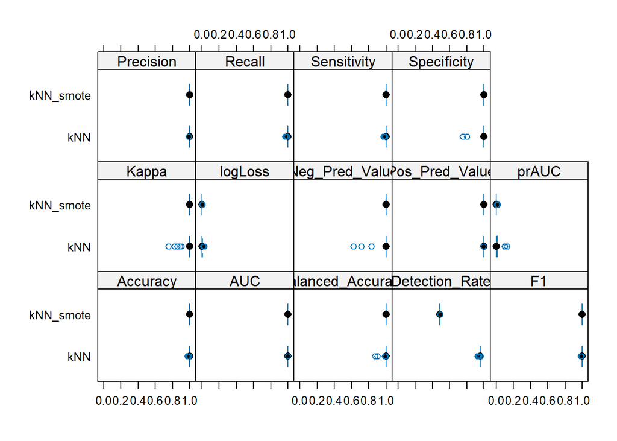

```r
# Boxplot for accuracy comparison
bwplot(results)
```

```r
# Pairwise comparisons
model_differences <- diff(results)
model_differences$statistics
```

```
$Accuracy
$Accuracy$kNN.diff.kNN_smote

    One Sample t-test

data:  x
t = -4.3431, df = 99, p-value = 3.4e-05
alternative hypothesis: true mean is not equal to 0
95 percent confidence interval:
 -0.003310344 -0.001234130
sample estimates:
   mean of x
-0.002272237



$AUC
$AUC$kNN.diff.kNN_smote

    One Sample t-test

data:  x
t = -1.3471, df = 99, p-value = 0.181
alternative hypothesis: true mean is not equal to 0
95 percent confidence interval:
 -7.345427e-05  1.404833e-05
sample estimates:
    mean of x
-2.970297e-05



$Balanced_Accuracy
$Balanced_Accuracy$kNN.diff.kNN_smote

    One Sample t-test

data:  x
t = -3.3612, df = 99, p-value = 0.001104
alternative hypothesis: true mean is not equal to 0
```

[output cut: 166 more lines]

```


$Specificity
$Specificity$kNN.diff.kNN_smote

    One Sample t-test

data:  x
t = -3.1089, df = 99, p-value = 0.002452
alternative hypothesis: true mean is not equal to 0
95 percent confidence interval:
 -0.031945471 -0.007054529
sample estimates:
mean of x
  -0.0195
```

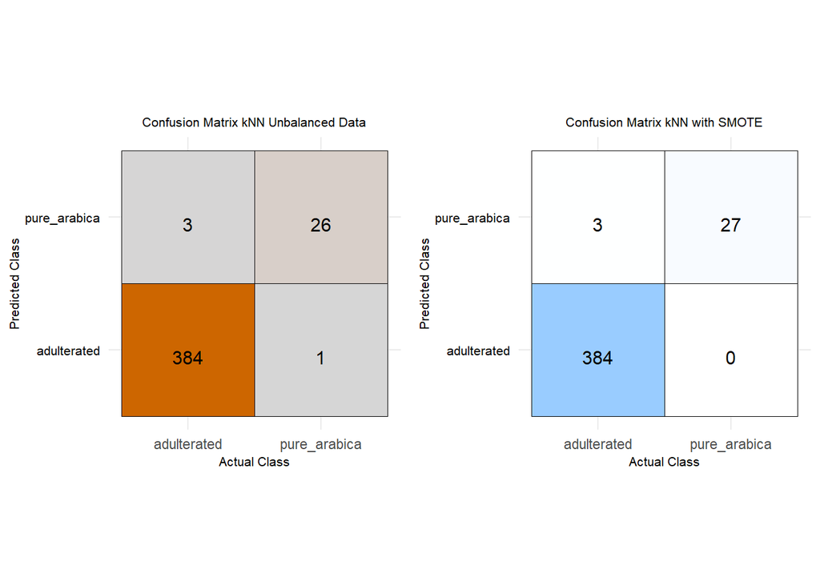

```r
p1<-ggplot(data = as.data.frame(test_knn_unmodified_CMtrx$table), aes(x = Reference, y = Prediction)) +
  geom_tile(aes(fill = Freq), color = "black") +
  geom_text(aes(label = sprintf("%0.0f", Freq)), vjust = 1,color = "black",size = 4) +
  scale_fill_gradient(low = "gray84", high = "darkorange3", name = "Frequency") +
  theme_minimal() +
  labs(x = "Actual Class", y = "Predicted Class", color = 'black',title = 'Confusion Matrix kNN Unbalanced Data')+
  theme(
    legend.position =  "none",
    axis.text.y = element_text(color = "black",size = 8),
    axis.title.x  = element_text(size = 8),
    axis.title.y = element_text(size = 8),aspect.ratio = 1,
    plot.title = element_text(size = 8,hjust = 0.5))


p2<-ggplot(data = as.data.frame(test_knn_smote_CMtrx$table), aes(x = Reference, y = Prediction)) +
  geom_tile(aes(fill = Freq), color = "black") +
  geom_text(aes(label = sprintf("%0.0f", Freq)), vjust = 1,color = "black",size = 4) +
  scale_fill_gradient(low = "white", high = "#99ccff", name = "Frequency") +
  theme_minimal() +
  labs(x = "Actual Class", y = "Predicted Class", color = 'black',title = 'Confusion Matrix kNN with SMOTE')+
  theme(
    legend.position =  "none",
    axis.text.y = element_text(color = "black",size = 8),
    axis.title.x  = element_text(size = 8),
    axis.title.y = element_text(size = 8),aspect.ratio = 1,
    plot.title = element_text(size = 8,hjust = 0.5))

grid.arrange(p1,p2, nrow =1)
```

## ROC Curve

```r
#SMOTE data
roc_curve <- roc(test_merged_smote_Preprocessed$binary_class, as.numeric(test_knn_smote))
```

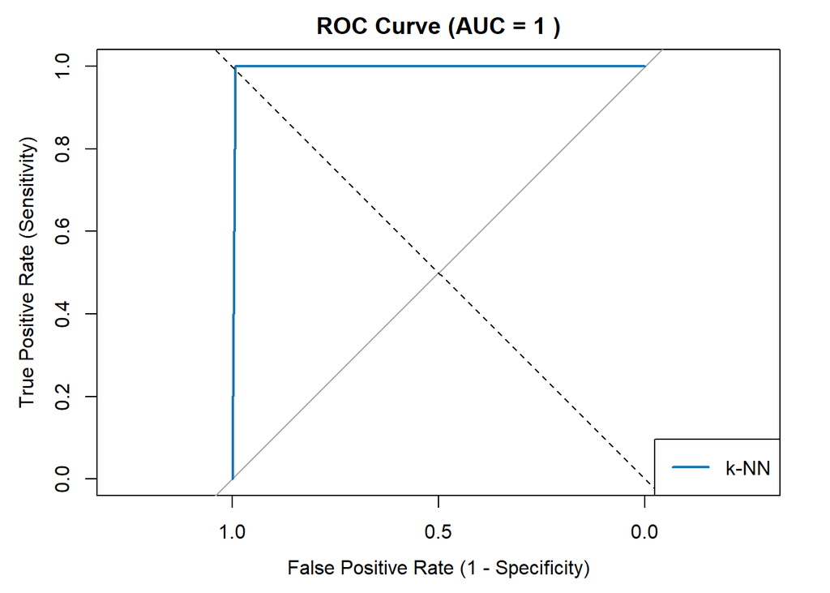

```r
auc_value <- auc(roc_curve)
plot(roc_curve, col = '#1f77b4', lwd = 2,
     main = paste("ROC Curve (AUC =", round(auc_value, 2), ")"),
     xlab = "False Positive Rate (1 - Specificity)",
     ylab = "True Positive Rate (Sensitivity)")
abline(a = 0, b = 1, lty = 2, col = "black")
legend("bottomright", legend = c("k-NN"), col = '#1f77b4', lwd = 2)
```

## Conclusion

- RFE and GA algorithms selected 92 variables, and k-NN models built on these reduced features achieved accuracies exceeding 0.99. The model based on SMOTE data also achieve a specificity of 1.0 suggesting it correctly identifies pure Arabica as such.